# Using `egor` to analyse ego-centered network data

Till Krenz

2023-03-16

## The `egor` Package

`egor` provides

- import functions
- egor object organizes ego-centered network, allowing for a smooth workflow
- dplyr methods: enable tidy data analysis strategies
- descriptive analysis (network composition, density, homophily, diversity)
- visualization (clustered graphs, egographs, egogram)
- interactive visualization app

An `egor` object contains all data levels associated with ego-centered network analysis, those levels are: ego, alter, alter-alter ties. By providing the `egor()`-function with `data.frames` containing data corresponding to these data levels, we construct an egor object. Here is an example of what the `data.frames` could look like. Pay attention to the ID variables connecting the levels with each other.

```
library(egor)
```

```r
data("alters32")
data("egos32")
data("aaties32")
```

First rows of alter data.

| .ALTID | .EGOID | sex | age | age.years | country | income |
| --- | --- | --- | --- | --- | --- | --- |
| 1 | 1 | m | 46 - 55 | 48 | USA | 45625 |
| 2 | 1 | m | 0 - 17 | 5 | Germany | 52925 |
| 3 | 1 | w | 26 - 35 | 35 | Australia | 60225 |
| 4 | 1 | w | 0 - 17 | 3 | Poland | 25550 |
| 5 | 1 | m | 66 - 100 | 97 | Australia | 45260 |
| 6 | 1 | w | 26 - 35 | 29 | Germany | 8395 |

First rows of ego data.

| .EGOID | sex | age | age.years | country | income |
| --- | --- | --- | --- | --- | --- |
| 1 | m | 56 - 65 | 63 | Australia | 29930 |
| 2 | m | 26 - 35 | 33 | Germany | 17885 |
| 3 | m | 66 - 100 | 74 | Germany | 20805 |
| 4 | w | 18 - 25 | 21 | Poland | 29565 |
| 5 | m | 0 - 17 | 9 | Germany | 15330 |
| 6 | m | 0 - 17 | 6 | Australia | 23360 |

First rows of alter-alter tie data.

| .EGOID | .SRCID | .TGTID | weight |
| --- | --- | --- | --- |
| 20 | 1 | 2 | 0.6666667 |
| 25 | 6 | 10 | 0.6666667 |
| 9 | 6 | 8 | 0.6666667 |
| 31 | 2 | 10 | 0.6666667 |
| 24 | 1 | 12 | 0.3333333 |
| 11 | 9 | 11 | 0.3333333 |

All three `data.frames` contain an egoID identifying a unique ego and connecting their personal data to the alter and alter-alter tie data. The alterID is in the alter data is reused in the alter-alter tie data in the Source and Target columns.

Let’s create an egor object from the data we just loaded.

```r
e1 <- egor(alters = alters32,
           egos = egos32,
           aaties = aaties32,
           ID.vars = list(
             ego = ".EGOID",
             alter = ".ALTID",
             source = ".SRCID",
             target = ".TGTID"))
e1
```

```
#> # EGO data (active): 32 × 6
#>   .egoID sex   age      age.years country   income
#> *  <dbl> <chr> <fct>        <int> <chr>      <dbl>
#> 1      1 m     56 - 65         63 Australia  29930
#> 2      2 m     26 - 35         33 Germany    17885
#> 3      3 m     66 - 100        74 Germany    20805
#> 4      4 w     18 - 25         21 Poland     29565
#> 5      5 m     0 - 17           9 Germany    15330
#> # … with 27 more rows
#> # ALTER data: 384 × 7
#>   .altID .egoID sex   age     age.years country   income
#> *  <int>  <dbl> <chr> <fct>       <int> <chr>      <dbl>
#> 1      1      1 m     46 - 55        48 USA        45625
#> 2      2      1 m     0 - 17          5 Germany    52925
#> 3      3      1 w     26 - 35        35 Australia  60225
#> # … with 381 more rows
#> # AATIE data: 1,056 × 4
#>   .egoID .srcID .tgtID weight
#> *  <int>  <int>  <int>  <dbl>
#> 1     20      1      2  0.667
#> 2     25      6     10  0.667
#> 3      9      6      8  0.667
#> # … with 1,053 more rows
```

An [`egor`] object is a [`list`] of three [`tibbles`], named “ego”, “alter” and “aatie”, containing ego, alter and alter-alter tie data.

## Import

There are currently three importing functions that read the data from disk and load them as an `egor` object.

```
read_openeddi()
read_egoweb()
read_egonet()
```

In addition there are three functions that help with the transformation of common data formats of ego-centered network data into egor objects:

```
onefile_to_egor()
twofiles_to_egor()
threefiles_to_egor()
```

## Manipulate

Manipulating an egor object can be done with base R functions or with `dplyr` verbs.

### Base R

The different data levels of an egor object can be manipulated using square bracket subsetting or the `subset()` function.

Ego level:

```r
e1[e1$ego$age.years > 35, ]
```

```
#> # EGO data (active): 19 × 6
#>   .egoID sex   age      age.years country   income
#> *  <dbl> <chr> <fct>        <int> <chr>      <dbl>
#> 1      1 m     56 - 65         63 Australia  29930
#> 2      3 m     66 - 100        74 Germany    20805
#> 3      7 m     66 - 100        84 Australia  19345
#> 4      8 w     66 - 100       100 Poland     35040
#> 5      9 m     36 - 45         38 USA        64605
#> # … with 14 more rows
#> # ALTER data: 228 × 7
#>   .altID .egoID sex   age     age.years country   income
#> *  <int>  <dbl> <chr> <fct>       <int> <chr>      <dbl>
#> 1      1      1 m     46 - 55        48 USA        45625
#> 2      2      1 m     0 - 17          5 Germany    52925
#> 3      3      1 w     26 - 35        35 Australia  60225
#> # … with 225 more rows
#> # AATIE data: 641 × 4
#>   .egoID .srcID .tgtID weight
#> *  <int>  <int>  <int>  <dbl>
#> 1     25      6     10  0.667
#> 2      9      6      8  0.667
#> 3      7      3      6  0.667
#> # … with 638 more rows
```

Alter level:

```r
subset(e1, e1$alter$sex == "w", unit = "alter")
```

```
#> # EGO data (active): 32 × 6
#>   .egoID sex   age      age.years country   income
#> *  <dbl> <chr> <fct>        <int> <chr>      <dbl>
#> 1      1 m     56 - 65         63 Australia  29930
#> 2      2 m     26 - 35         33 Germany    17885
#> 3      3 m     66 - 100        74 Germany    20805
#> 4      4 w     18 - 25         21 Poland     29565
#> 5      5 m     0 - 17           9 Germany    15330
#> # … with 27 more rows
#> # ALTER data: 204 × 7
#>   .altID .egoID sex   age     age.years country   income
#> *  <int>  <dbl> <chr> <fct>       <int> <chr>      <dbl>
#> 1      3      1 w     26 - 35        35 Australia  60225
#> 2      4      1 w     0 - 17          3 Poland     25550
#> 3      6      1 w     26 - 35        29 Germany     8395
#> # … with 201 more rows
#> # AATIE data: 300 × 4
#>   .egoID .srcID .tgtID weight
#> *  <int>  <int>  <int>  <dbl>
#> 1     25      6     10  0.667
#> 2      9      6      8  0.667
#> 3      7      3      6  0.667
#> # … with 297 more rows
```

Alter-alter tie level:

```r
subset(e1, e1$aatie$weight > 0.5, unit = "aatie")
```

```
#> # EGO data (active): 32 × 6
#>   .egoID sex   age      age.years country   income
#> *  <dbl> <chr> <fct>        <int> <chr>      <dbl>
#> 1      1 m     56 - 65         63 Australia  29930
#> 2      2 m     26 - 35         33 Germany    17885
#> 3      3 m     66 - 100        74 Germany    20805
#> 4      4 w     18 - 25         21 Poland     29565
#> 5      5 m     0 - 17           9 Germany    15330
#> # … with 27 more rows
#> # ALTER data: 384 × 7
#>   .altID .egoID sex   age     age.years country   income
#> *  <int>  <dbl> <chr> <fct>       <int> <chr>      <dbl>
#> 1      1      1 m     46 - 55        48 USA        45625
#> 2      2      1 m     0 - 17          5 Germany    52925
#> 3      3      1 w     26 - 35        35 Australia  60225
#> # … with 381 more rows
#> # AATIE data: 721 × 4
#>   .egoID .srcID .tgtID weight
#> *  <int>  <int>  <int>  <dbl>
#> 1     20      1      2  0.667
#> 2     25      6     10  0.667
#> 3      9      6      8  0.667
#> # … with 718 more rows
```

### activate() and dplyr verbs

An `egor` object can be manipulated with dplyr verbs. Using the activate() command, the data level to execute manipulations on, can be changed. This concept is borrowed from the tidygraph package.

If the manipulation leads to the deletion of egos, the respective alters and alter-alter ties are deleted as well. Similarly deletions of alters lead to the exclusion of the alter-alter ties of the deleted alters.

```r
e1 %>%
  filter(income > 36000)
```

```
#> # EGO data (active): 10 × 6
#>   .egoID sex   age     age.years country   income
#> *  <dbl> <chr> <fct>       <int> <chr>      <dbl>
#> 1      9 m     36 - 45        38 USA        64605
#> 2     10 m     0 - 17         14 Australia  49275
#> 3     11 w     26 - 35        27 Germany    37960
#> 4     12 m     56 - 65        57 Germany    54750
#> 5     15 w     26 - 35        28 Germany    46720
#> # … with 5 more rows
#> # ALTER data: 120 × 7
#>   .altID .egoID sex   age     age.years country   income
#> *  <int>  <dbl> <chr> <fct>       <int> <chr>      <dbl>
#> 1      1      9 m     46 - 55        48 USA        45625
#> 2      2      9 m     0 - 17          5 Germany    52925
#> 3      3      9 w     26 - 35        35 Australia  60225
#> # … with 117 more rows
#> # AATIE data: 333 × 4
#>   .egoID .srcID .tgtID weight
#> *  <int>  <int>  <int>  <dbl>
#> 1     20      1      2  0.667
#> 2      9      6      8  0.667
#> 3     11      9     11  0.333
#> # … with 330 more rows
```

```r
e1 %>%
  activate(alter) %>%
  filter(country %in% c("USA", "Poland"))
```

```
#> # EGO data: 32 × 6
#>   .egoID sex   age      age.years country   income
#> *  <dbl> <chr> <fct>        <int> <chr>      <dbl>
#> 1      1 m     56 - 65         63 Australia  29930
#> 2      2 m     26 - 35         33 Germany    17885
#> 3      3 m     66 - 100        74 Germany    20805
#> # … with 29 more rows
#> # ALTER data (active): 180 × 7
#>   .altID .egoID sex   age     age.years country income
#> *  <int>  <dbl> <chr> <fct>       <int> <chr>    <dbl>
#> 1      1      1 m     46 - 55        48 USA      45625
#> 2      4      1 w     0 - 17          3 Poland   25550
#> 3      7      1 m     26 - 35        32 USA      54020
#> 4      8      1 w     46 - 55        49 USA      60955
#> 5     11      1 w     46 - 55        54 Poland    9490
#> # … with 175 more rows
#> # AATIE data: 218 × 4
#>   .egoID .srcID .tgtID weight
#> *  <int>  <int>  <int>  <dbl>
#> 1     31      2     10  0.667
#> 2     24      1     12  0.333
#> 3      7      3      6  0.667
#> # … with 215 more rows
```

```r
e1 %>%
  activate(aatie) %>%
  filter(weight > 0.7)
```

```
#> # EGO data: 32 × 6
#>   .egoID sex   age      age.years country   income
#> *  <dbl> <chr> <fct>        <int> <chr>      <dbl>
#> 1      1 m     56 - 65         63 Australia  29930
#> 2      2 m     26 - 35         33 Germany    17885
#> 3      3 m     66 - 100        74 Germany    20805
#> # … with 29 more rows
#> # ALTER data: 384 × 7
#>   .altID .egoID sex   age     age.years country   income
#> *  <int>  <dbl> <chr> <fct>       <int> <chr>      <dbl>
#> 1      1      1 m     46 - 55        48 USA        45625
#> 2      2      1 m     0 - 17          5 Germany    52925
#> 3      3      1 w     26 - 35        35 Australia  60225
#> # … with 381 more rows
#> # AATIE data (active): 374 × 4
#>   .egoID .srcID .tgtID weight
#> *  <int>  <int>  <int>  <dbl>
#> 1     26      2     10      1
#> 2     15      6     10      1
#> 3     16      3      6      1
#> 4     24      2      8      1
#> 5     26      6     11      1
#> # … with 369 more rows
```

## Analyse

Try these function to analyse you `egor` object.

### Summary

```r
summary(e1)
```

```
#> 32 Egos/ Ego Networks
#> 384 Alters
#> Min. Netsize 12
#> Average Netsize 12
#> Max. Netsize 12
#> Average Density 0.5
#> Alter survey design:
#>   Maximum nominations: Inf
```

### Density

```r
ego_density(e1)
```

```
#> # A tibble: 32 × 2
#>    .egoID density
#>     <dbl>   <dbl>
#>  1      1   0.485
#>  2      2   0.5
#>  3      3   0.5
#>  4      4   0.409
#>  5      5   0.561
#>  6      6   0.455
#>  7      7   0.652
#>  8      8   0.485
#>  9      9   0.515
#> 10     10   0.515
#> # … with 22 more rows
```

### Composition

```r
composition(e1, "age") %>%
  head() %>%
  kable()
```

| .egoID | 0 - 17 | 18 - 25 | 26 - 35 | 36 - 45 | 46 - 55 | 56 - 65 | 66 - 100 |
| --- | --- | --- | --- | --- | --- | --- | --- |
| 1 | 0.1666667 | NA | 0.2500000 | NA | 0.3333333 | 0.0833333 | 0.1666667 |
| 2 | 0.3333333 | 0.1666667 | NA | 0.0833333 | 0.1666667 | NA | 0.2500000 |
| 3 | 0.1666667 | 0.1666667 | 0.0833333 | NA | 0.1666667 | 0.0833333 | 0.3333333 |
| 4 | 0.0833333 | 0.0833333 | 0.1666667 | NA | 0.2500000 | 0.0833333 | 0.3333333 |
| 5 | 0.2500000 | 0.1666667 | NA | 0.0833333 | 0.1666667 | NA | 0.3333333 |
| 6 | 0.1666667 | 0.0833333 | 0.2500000 | NA | 0.2500000 | 0.0833333 | 0.1666667 |

### Diversity

```r
alts_diversity_count(e1, "age")
```

```
#> # A tibble: 32 × 2
#>    .egoID diversity
#>     <dbl>     <dbl>
#>  1      1         5
#>  2      2         5
#>  3      3         6
#>  4      4         6
#>  5      5         5
#>  6      6         6
#>  7      7         5
#>  8      8         5
#>  9      9         5
#> 10     10         5
#> # … with 22 more rows
```

```r
alts_diversity_entropy(e1, "age")
```

```
#> # A tibble: 32 × 2
#>    .egoID entropy
#>     <dbl>   <dbl>
#>  1      1    2.19
#>  2      2    2.19
#>  3      3    2.42
#>  4      4    2.36
#>  5      5    2.19
#>  6      6    2.46
#>  7      7    2.08
#>  8      8    2.13
#>  9      9    2.19
#> 10     10    2.19
#> # … with 22 more rows
```

### Ego-Alter Homophily (EI-Index)

```r
comp_ei(e1, "age", "age")
```

```
#> # A tibble: 32 × 2
#>    .egoID    ei
#>     <dbl> <dbl>
#>  1      1 0.833
#>  2      2 1
#>  3      3 0.333
#>  4      4 0.833
#>  5      5 0.5
#>  6      6 0.667
#>  7      7 0.333
#>  8      8 0.333
#>  9      9 1
#> 10     10 0.333
#> # … with 22 more rows
```

### EI-Index for Alter-Alter Ties

```r
EI(e1, "age") %>%
  head() %>%
  kable()
```

| .egoID | ei | 0 - 17 | 26 - 35 | 46 - 55 | 56 - 65 | 66 - 100 | 18 - 25 | 36 - 45 |
| --- | --- | --- | --- | --- | --- | --- | --- | --- |
| 1 | 0.5000000 | -0.1764706 | 0.25 | 1.0000000 | NaN | 1.0000000 | NA | NA |
| 2 | -0.0526316 | 0.1688312 | NA | -0.2500000 | NA | -0.3500000 | 1.0000000 | NaN |
| 3 | -0.1692308 | 1.0000000 | NaN | 1.0000000 | NaN | -0.2213740 | -0.2903226 | NA |
| 4 | 0.0132159 | NaN | 1.00 | -0.2413793 | NaN | 0.2000000 | NaN | NA |
| 5 | 0.0163934 | 1.0000000 | NA | -0.3333333 | NA | -0.0322581 | -0.3793103 | NaN |
| 6 | 0.1076923 | -0.3333333 | 1.00 | 0.1818182 | NaN | -0.3793103 | NaN | NA |

### Count attribute combinations in alter-alter ties/ dyads

```r
# return results as "wide" tibble
  count_dyads(
    object = e1,
    alter_var_name = "country"
  )
```

```
#> # A tibble: 32 × 11
#>    .egoID dy_cou_Austr…¹ dy_co…² dy_co…³ dy_co…⁴ dy_co…⁵ dy_co…⁶ dy_co…⁷ dy_co…⁸
#>     <dbl>          <int>   <int>   <int>   <int>   <int>   <int>   <int>   <int>
#>  1      1              2       6       3       3       3       4       6       2
#>  2      2              0       2       0       1       5       9       4       8
#>  3      3              4       6       4       4       2       1       7       2
#>  4      4              1       1       1       3       1       3       7       6
#>  5      5              2      11       4       2       4       5       6       2
#>  6      6              2       1       1       8       0       2       4       7
#>  7      7              0       5       7       2       5      15       3       3
#>  8      8              1       7       1       6       4       3       7       2
#>  9      9              1       6       4       8       2       2       7       2
#> 10     10              0       3       1       2       4      11       6       3
#> # … with 22 more rows, 2 more variables: dy_cou_USA_USA <int>,
#> #   dy_cou_Poland_Poland <int>, and abbreviated variable names
#> #   ¹dy_cou_Australia_Australia, ²dy_cou_Australia_Germany,
#> #   ³dy_cou_Australia_Poland, ⁴dy_cou_Australia_USA, ⁵dy_cou_Germany_Germany,
#> #   ⁶dy_cou_Germany_Poland, ⁷dy_cou_Germany_USA, ⁸dy_cou_Poland_USA
```

```r
# return results as "long" tibble
  count_dyads(
    object = e1,
    alter_var_name = "country",
    return_as = "long"
  )
```

```
#> # A tibble: 278 × 3
#>    .egoID dyads                   n
#>     <dbl> <chr>               <int>
#>  1      1 Australia_Australia     2
#>  2      1 Australia_Germany       6
#>  3      1 Australia_Poland        3
#>  4      1 Australia_USA           3
#>  5      1 Germany_Germany         3
#>  6      1 Germany_Poland          4
#>  7      1 Germany_USA             6
#>  8      1 Poland_USA              2
#>  9      1 USA_USA                 3
#> 10      2 Australia_Germany       2
#> # … with 268 more rows
```

### `comp_ply()`

`comp_ply()` applies a user-defined function on an alter attribute and returns a numeric vector with the results. It can be used to apply base R functions like `sd()`, `mean()` or functions from other packages.

```r
e2 <- make_egor(15, 32)
comp_ply(e2, "age.years", sd, na.rm = TRUE)
```

```
#> # A tibble: 15 × 2
#>    .egoID result
#>     <dbl>  <dbl>
#>  1      1   27.0
#>  2      2   25.2
#>  3      3   25.3
#>  4      4   28.9
#>  5      5   26.8
#>  6      6   28.9
#>  7      7   27.3
#>  8      8   28.5
#>  9      9   25.2
#> 10     10   25.1
#> 11     11   26.8
#> 12     12   27.3
#> 13     13   27.2
#> 14     14   28.3
#> 15     15   39.0
```

## Visualize

### Clustered Graphs

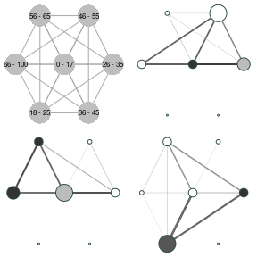

```r
data("egor32")

# Simplify networks to clustered graphs, stored as igraph objects
graphs <- clustered_graphs(egor32, "age")

# Visualize
par(mfrow = c(2,2), mar = c(0,0,0,0))
vis_clustered_graphs(graphs[1:3],
                     node.size.multiplier = 1,
                     edge.width.multiplier = 1,
                     label.size = 0.6)
```

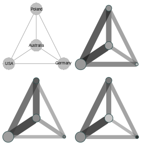

```r
graphs2 <- clustered_graphs(make_egor(50, 50)[1:4], "country")

vis_clustered_graphs(graphs2[1:3],
                     node.size.multiplier = 1,
                     edge.width.multiplier = 3,
                     label.size = 0.6,
                     labels = FALSE)
```

### `igraph` & `network` plotting

- `as_igraph()` converts an `egor` object to a list of igraph objects.
- `as_network()` converts an `egor` object to a list of network objects.

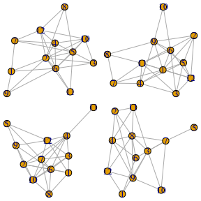

```r
par(mar = c(0, 0, 0, 0), mfrow = c(2, 2))
purrr::walk(as_igraph(egor32)[1:4], plot)
```

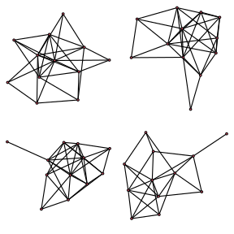

```r
purrr::walk(as_network(egor32)[1:4], plot)
```

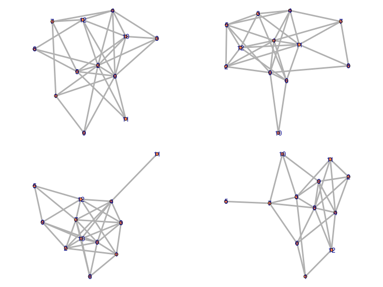

```r
plot(egor32)
```

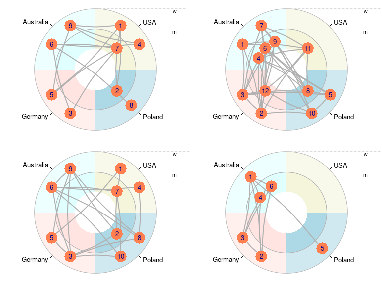

```r
plot(make_egor(32,16), venn_var = "sex", pie_var = "country", type = "egogram")
```

### Shiny App for Visualization

`egor_vis_app()` starts a Shiny app which offers a graphical interface for adjusting the visualization parameters of the networks stored in an `egor` object.

```
egor_vis_app(egor32)
```

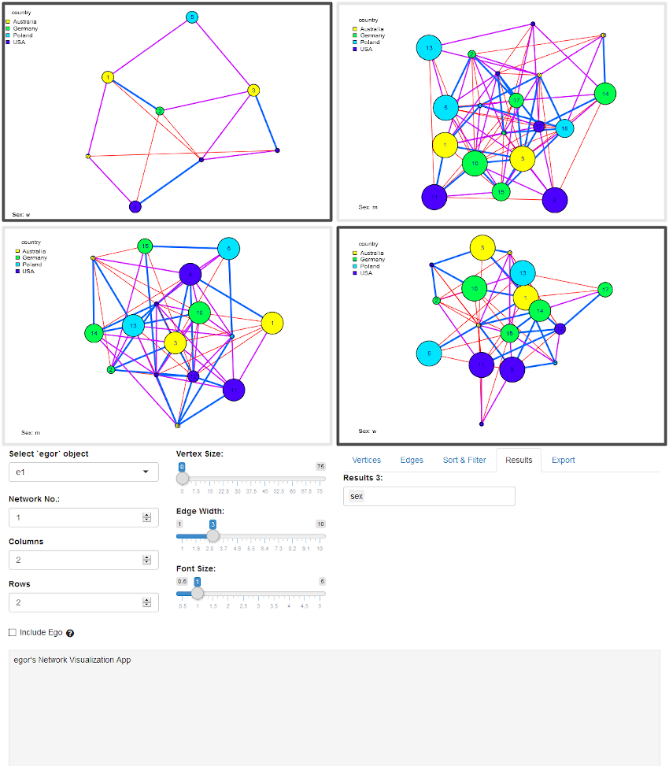

egor Vis App

## Conversions

With `as_igraph()` and `as_network()` all ego networks are transformed into a list of igraph/network objects.